# demo

## AI Memory Sytem

This is the demonstration of ai memory system

[figure not shown]

```python
import os

from function.vector_store import get_connection
from utils.embedding import get_nomic_embedding

PGVECTOR_CONN = os.environ.get("PGVECTOR_CONN")

kb = get_connection(connection=PGVECTOR_CONN, embedding_model=get_nomic_embedding(), collection_name="test_collection")
```

### Working Memory

Working memory encompasses your active understanding and contextualization of immediate information requiring dynamic processing. For a chatbot, this represents the maintenance and manipulation of conversational context observed throughout real-time interactions.

The type of information maintained in working memory consists of active messages and roles, current task/goal parameters, immediate state representations, and contextual processing requirements. This includes message history with associated metadata, conversation state vectors, goal hierarchies, and temporary computational results requiring immediate access.

[figure not shown]

It's like a mental workspace where you can briefly keep information active while performing other operations on it.

```python
# https://chat-ai.hari.pitt.edu/c/b5787199-4612-4973-add3-182bf36d98eb
```

### Long term memory & Short term memory

[figure not shown]

Use reasoning node to determine the necessarity of concluding a user query to long term memory and execute infering procedure if worthy.

```python
from langchain_core.messages import AIMessage, HumanMessage

from classes.Memory import BaseMemory, MemoryItem
from function.answer_generation import generate_answer_with_memory
from function.mem_proc import memory_extract_decision, summarize_lstm_from_query
from function.vector_store import add_to_memory

conversation = []
stm_context = []

while True:
    # Get user input
    query = input("User:")
    print(f"HUMAN: {query}")

    # Exit the loop
    if query.upper() == "EXIT":
        break

    conversation.append(HumanMessage(content=query))

    isWorthy: bool = memory_extract_decision(query=query)  # noqa: N816
    if isWorthy is True:
        print("<AI Internal>: Activate Memory System")

        # Distill key information
        summary: BaseMemory = summarize_lstm_from_query(query=query)

        if summary.content and summary.type != "N/A":
            print("<AI Internal>: Pass")

            # Persis LTM / instruct following converstation if STM
            memo = MemoryItem(
                **summary.model_dump(),
                user_id="drake",
                source="HUMAN",
            )

            memo_sentence = memo.convert_to_sentence()

            if memo.level == "LTM":
                # TODO: add LTM to the vector store
                res = add_to_memory(memo)
                stm_context.append(memo_sentence)
                if res is not None:
                    print("<AI Internal>: Memory persisted")
            else:
                print("<AI Internal>: Classified as STM add to context")
                stm_context.append(memo_sentence)

        print(f"<AI Internal>: {memo_sentence}")
    else:
        print("<AI Internal>: Not worthy ")

    answer: AIMessage = generate_answer_with_memory(
        question=query,
        ltm_context=[],
        stm_context=stm_context,
        conversation_history=conversation[-4:-1] if len(conversation) > 3 else conversation,
    )

    conversation.append(answer)

    print(f"AI: {answer.content}")

    print("--------------------------------")
```

```python
# New conversation without retrieval

res = generate_answer_with_memory("what is my name and my favorite food so far ?")

print(f"AI: {res.content}")
```

```
AI: Since we’ve just started our conversation and I don’t have any long-term memory or chat history to reference, I don’t yet know your name or favorite food. But I’d love to learn more about you! Could you share your name and your favorite food with me? That way, I can remember these details for ou…

For example, you could say:
*"My name is [Your Name], and I love [Your Favorite Food]!"*

I’m here to listen and support you in any way I can. 💙
```

```python
# New converstation with retrieval


from embedding.vector_store import recall_memory
from langchain_core.documents import Document

user_query = "what is my name and my favorite food so far ?"

res: list[Document] = recall_memory(query=user_query, user_id="drake")

for item in res:
    print(f"<AI Internal>: Retrieved relevant memory: {item.page_content}")

answer = generate_answer_with_memory(
    question=user_query,
    ltm_context=res,
)

print(f"AI: {answer.content}")
```

```
<AI Internal>: Retrieved relevant memory: user's name is Drake
<AI Internal>: Retrieved relevant memory: user's dad is experiencing increased forgetfulness.
AI: Hello, Drake! Based on my long-term memory, I know your name is Drake, and you're caring for your dad who is experiencing increased forgetfulness—a situation that I know can be both challenging and emotionally heavy at times.

As for your favorite food, it seems we haven’t had the chance to discuss that yet. Would you like to share what you enjoy? I’d love to learn more about you so I can offer support that feels personal and meaningful.

How are you feeling today? Is there anything specific you’d like to talk about regarding your dad’s care or your own well-being? I’m here to listen and help.
```

#### Evaluation

First, we will take a look at how smart the determination node is. That is to say, can LLM make right decision on whether or not this query contains valuable information

```python
import pandas as pd

df = pd.read_csv("data/memory_eval_dataset.csv")  # noqa: PD901

df.head()
```

|  | Question | C-worthy | T-Decision | C-Category | C-Conclusion |
| --- | --- | --- | --- | --- | --- |
| 0 | Hi CaLM, I’m Michael Chen, a 49‑year‑old part‑... | True | True | BIO_INFO | NaN |
| 1 | My wife Jenna can only pitch in on weekends; h... | True | True | SOCIAL_CONNECTIONS | NaN |
| 2 | Robert usually grows restless around 7 p.m. he... | True | True | CARE_GIVING | NaN |
| 3 | Our daughter Emily lives in Boston; what are s... | True | True | SOCIAL_CONNECTIONS | NaN |
| 4 | I absorb info fastest in concise checklists—co... | True | True | PREFERENCES | NaN |

```python
for index, row in df.iterrows():
    query = row["Question"]

    res = memory_extract_decision(query=query)

    # Update the T-Decision column with the result from memory_extract_decision
    df.at[index, "T-Decision"] = res  # noqa: PD008

    # Print the current row to monitor progress
    print(f"Processed row {index}: {query[:50]}... - Decision: {res}")

df.to_csv("data/memory_eval_dataset.csv", index=False)
```

[output not shown]

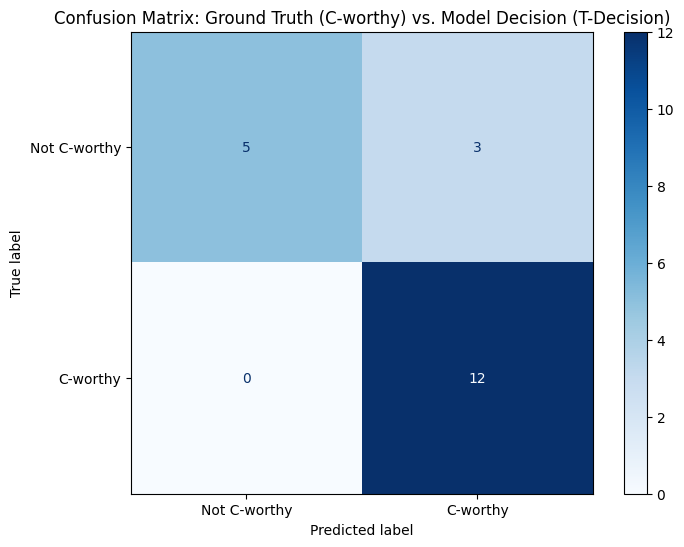

```
Accuracy: 0.8500
Precision: 0.8000
Recall: 1.0000
F1 Score: 0.8889
```

```python
import matplotlib.pyplot as plt
from sklearn.metrics import ConfusionMatrixDisplay, confusion_matrix

# Filter out rows where T-Decision is NaN
filtered_df = df.dropna(subset=["T-Decision"])

# Convert boolean values to integers for confusion matrix
y_true = filtered_df["C-worthy"].astype(bool)
y_pred = filtered_df["T-Decision"].astype(bool)

# Create confusion matrix
cm = confusion_matrix(y_true, y_pred)

# Display confusion matrix
fig, ax = plt.subplots(figsize=(8, 6))
disp = ConfusionMatrixDisplay(confusion_matrix=cm, display_labels=["Not C-worthy", "C-worthy"])
disp.plot(cmap="Blues", ax=ax)
plt.title("Confusion Matrix: Ground Truth (C-worthy) vs. Model Decision (T-Decision)")
plt.show()

# Calculate accuracy, precision, recall, and F1 score
tn, fp, fn, tp = cm.ravel()
accuracy = (tp + tn) / (tp + tn + fp + fn)
precision = tp / (tp + fp) if (tp + fp) > 0 else 0
recall = tp / (tp + fn) if (tp + fn) > 0 else 0
f1 = 2 * precision * recall / (precision + recall) if (precision + recall) > 0 else 0

print(f"Accuracy: {accuracy:.4f}")
print(f"Precision: {precision:.4f}")
print(f"Recall: {recall:.4f}")
print(f"F1 Score: {f1:.4f}")
```

#### Memory Operation

```python
import os

from function.vector_store import get_connection
from utils.embedding import get_nomic_embedding

PGVECTOR_CONN = os.environ.get("PGVECTOR_CONN")

kb = get_connection(connection=PGVECTOR_CONN, embedding_model=get_nomic_embedding(), collection_name="test_collection")
```

```python
import sys

from langchain_core.messages import AIMessage, HumanMessage

from classes.Memory import BaseMemory, MemoryItem
from function.answer_generation import generate_answer_with_memory
from function.mem_proc import (
    classify_operation,
    memory_extract_decision,
    summarize_lstm_from_query,
)
from function.vector_store import add_to_memory, get_connection

query = "hello, my name is Jay, please remember it."

isWorthy: bool = memory_extract_decision(query=query)  # noqa: N816

print(f"<AI Internal>: {isWorthy}")

if isWorthy is True:
    print("<AI Internal>: Activate Memory System")

    # Distill key information
    summary: BaseMemory = summarize_lstm_from_query(query=query)

    if summary.content and summary.type != "N/A":
        print("<AI Internal>: Checksum Pass")

        memo = MemoryItem(
            **summary.model_dump(),
            user_id="drake",
            source="HUMAN",
        )

        memo_sentence = memo.convert_to_sentence()

        print(f"<AI Internal>: New memory item - {memo_sentence}")

        operation:str | MemoryItem = classify_operation(query=query, user_id="test_user", new_memory=memo, kb=kb)

        if operation == "APPEND" :
            print("<AI Internal>: Classified as STM and appended to current context")
            sys.exit(0)

        print(f"<AI Internal>: Operation - {operation}")
```

```
<AI Internal>: True
<AI Internal>: Activate Memory System
<AI Internal>: Checksum Pass
<AI Internal>: New memory item - The user's user name is user's name is Jay.
<AI Internal>: Premise Memories are []
<AI Internal>: Operation - The user's user name is user's name is Jay.
```

Previous memory in collection

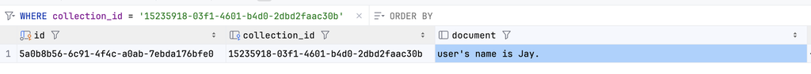

```python
import sys

from langchain_core.messages import AIMessage, HumanMessage

from classes.Memory import BaseMemory, MemoryItem
from function.answer_generation import generate_answer_with_memory
from function.mem_proc import (
    classify_operation,
    memory_extract_decision,
    summarize_lstm_from_query,
)
from function.vector_store import add_to_memory, get_connection

query = "Hi, my name is Brad. Please remember this."

isWorthy: bool = memory_extract_decision(query=query)  # noqa: N816

print(f"<AI Internal>: {isWorthy}")

if isWorthy is True:
    print("<AI Internal>: Activate Memory System")

    # Distill key information
    summary: BaseMemory = summarize_lstm_from_query(query=query)

    if summary.content and summary.type != "N/A":
        print("<AI Internal>: Checksum Pass")

        memo = MemoryItem(
            **summary.model_dump(),
            user_id="test_user",
            source="HUMAN",
        )

        memo_sentence = memo.convert_to_sentence()

        print(f"<AI Internal>: New memory item - {memo_sentence}")

        operation:str | MemoryItem = classify_operation(query=query, user_id="test_user", new_memory=memo, kb=kb)

        if operation == "APPEND" :
            print("<AI Internal>: Classified as STM and appended to current context")
            sys.exit(0)

        print(f"<AI Internal>: Operation - {operation}")
```

```
<AI Internal>: True
<AI Internal>: Activate Memory System
<AI Internal>: Checksum Pass
<AI Internal>: New memory item - The user's user name is user's name is Brad.
<AI Internal>: Premise Memories are [Document(id='5a0b8b56-6c91-4f4c-a0ab-7ebda176bfe0', metadata={'id': 98804343867226373704967558419700997605, 'type': 'user name', 'level': 'LTM', 'topic': ['name', 'bio', 'identity'], 'source': 'HUMAN', 'user_id': 'test_user', 'category': 'BIO_INFO', 'timestamp': …
<AI Internal>: Operation - UPDATED
```

Updated memory

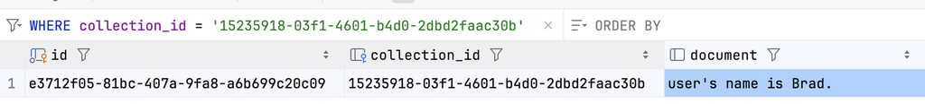

```python
import sys

from langchain_core.messages import AIMessage, HumanMessage

from classes.Memory import BaseMemory, MemoryItem
from function.answer_generation import generate_answer_with_memory
from function.mem_proc import (
    classify_operation,
    memory_extract_decision,
    summarize_lstm_from_query,
)
from function.vector_store import add_to_memory, get_connection

query = "How do I get my loved one to take a shower, change their clothes, or brush their teeth when they are refusing?"

isWorthy: bool = memory_extract_decision(query=query)  # noqa: N816

print(f"<AI Internal>: {isWorthy}")

if isWorthy is True:
    print("<AI Internal>: Activate Memory System")

    # Distill key information
    summary: BaseMemory = summarize_lstm_from_query(query=query)

    if summary.content and summary.type != "N/A":
        print("<AI Internal>: Checksum Pass")

        memo = MemoryItem(
            **summary.model_dump(),
            user_id="test_user",
            source="HUMAN",
        )

        memo_sentence = memo.convert_to_sentence()

        print(f"<AI Internal>: New memory item - {memo_sentence}")

        operation:str | MemoryItem = classify_operation(query=query, user_id="test_user", new_memory=memo, kb=kb)

        if operation == "APPEND" :
            print("<AI Internal>: Classified as STM and appended to current context")
            sys.exit(0)

        print(f"<AI Internal>: Operation - {operation}")
```

```
<AI Internal>: True
<AI Internal>: Activate Memory System
<AI Internal>: Checksum Pass
<AI Internal>: New memory item - The user's care recipient behavior is user's loved one is refusing to perform personal hygiene tasks.
<AI Internal>: Premise Memories are []
<AI Internal>: Operation - ADDED
```

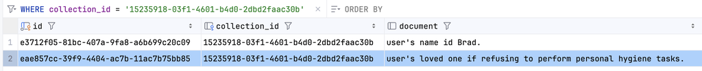

```python
import sys

from langchain_core.messages import AIMessage, HumanMessage

from classes.Memory import BaseMemory, MemoryItem
from function.answer_generation import generate_answer_with_memory
from function.mem_proc import (
    classify_operation,
    memory_extract_decision,
    summarize_lstm_from_query,
)
from function.vector_store import add_to_memory, get_connection

query = "so far, my care recipient is able to take care herself, should I still remind her this ? I don't want to irritate her."

isWorthy: bool = memory_extract_decision(query=query)  # noqa: N816

print(f"<AI Internal>: {isWorthy}")

if isWorthy is True:
    print("<AI Internal>: Activate Memory System")

    # Distill key information
    summary: BaseMemory = summarize_lstm_from_query(query=query)

    if summary.content and summary.type != "N/A":
        print("<AI Internal>: Checksum Pass")

        memo = MemoryItem(
            **summary.model_dump(),
            user_id="test_user",
            source="HUMAN",
        )

        memo_sentence = memo.convert_to_sentence()

        print(f"<AI Internal>: New memory item - {memo_sentence}")

        operation:str | MemoryItem = classify_operation(query=query, user_id="test_user", new_memory=memo, kb=kb)

        if operation == "APPEND" :
            print("<AI Internal>: Classified as STM and appended to current context")
            sys.exit(0)

        print(f"<AI Internal>: Operation - {operation}")
```

```
<AI Internal>: True
<AI Internal>: Activate Memory System
<AI Internal>: Checksum Pass
<AI Internal>: New memory item - The user's care recipient condition is user's care recipient is currently able to take care of herself.
<AI Internal>: Premise Memories are [Document(id='eae857cc-39f9-4404-ac7b-11ac7b75bb85', metadata={'id': 80772381298530622521012228232751961359, 'type': 'care recipient condition', 'level': 'LTM', 'topic': ['caregiving', 'independence', 'reminders'], 'source': 'HUMAN', 'user_id': 'test_user', 'categ…
<AI Internal>: Operation - UPDATED
```

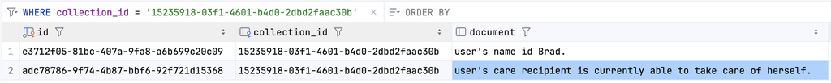